# Hawaiian Airlines Flight Delay Analysis

## by Gilvan Reis

March - 2021

## Investigation Overview

The main objective of this analysis was to find out what are the main causes of delays on Hawaiian Airlines flights, identifying opportunities for improvements in the company.

## Dataset Overview

The study was conducted on 20,932 operating records from 17 carriers limited to the US area during 2019. A flight is considered to be delayed when it departs at least 15 minutes later than expected.

## Delay Causes

There are five delay causes:

- **carrier**: due to air carrier (e.g. maintenance or crew problems, aircraft cleaning, baggage loading, fueling, etc.).
- **weather**: due to extreme weather.
- **nas**: due to National Aviation System (e.g. non-extreme weather conditions, airport operations, heavy traffic volume, and air traffic control).
- **security**: due to security (e.g. evacuation of a terminal or concourse, re-boarding of aircraft because of security breach, inoperative screening equipment and/or long lines in excess of 29 minutes at screening areas).
- **late aircraft**: due to a previous flight using the same aircraft being late.

**Late aircraft** is the main cause of delays (36.9%). **Security** delays are very rare (0.2%).

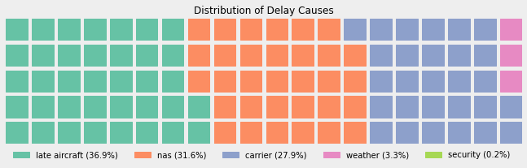

## Delayed Flights by Carrier

Hawaiian Airlines has the **lowest** proportion of delayed flights (11.4%) when compared to other carriers.

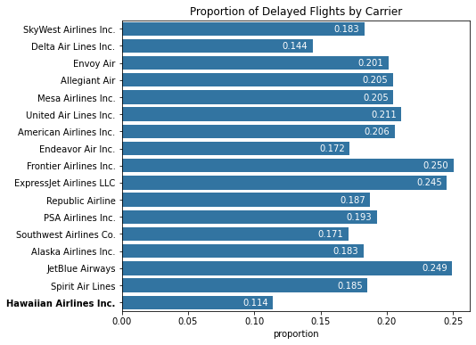

## Delayed Flights by Month by Carrier

Hawaiian Airlines has a very low and consistent proportion of delayed flights throughout the year, with **February** being the month with the highest proportion of delayed flights.

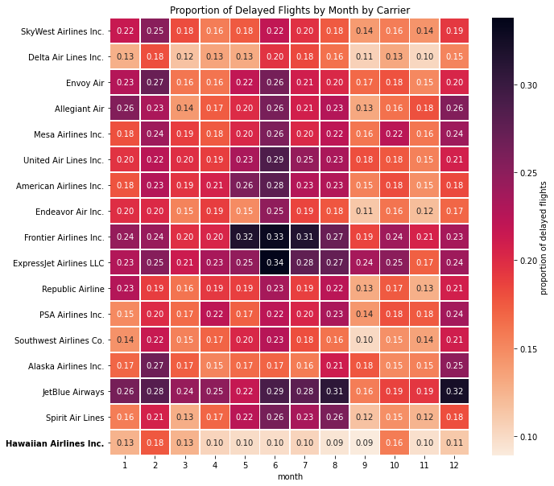

## Delay Cause by Month by Carrier

However, when comparing the main cause of delays in each carrier, we can observe different behavior on Hawaiian Airlines. The main cause of its delays is due to **carrier**.

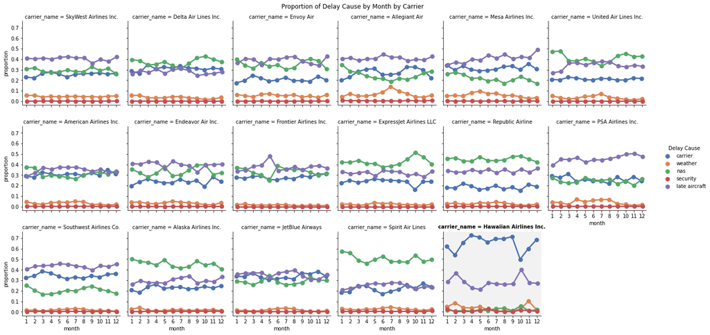

## Flights Delayed due Carrier Problems

When looking at the proportion of carrier problems in each carrier, we can see that Hawaiian Airlines differs from the others with a much higher proportion, indicating that there is an **opportunity for improvement** in this area for the company.

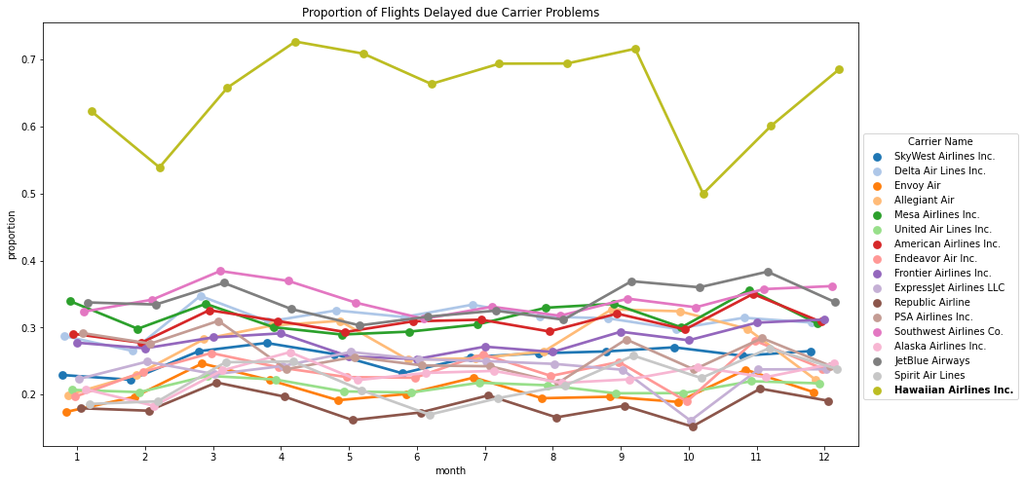